There seems to be some relation between pH and fixed acidity from the plot matrix above

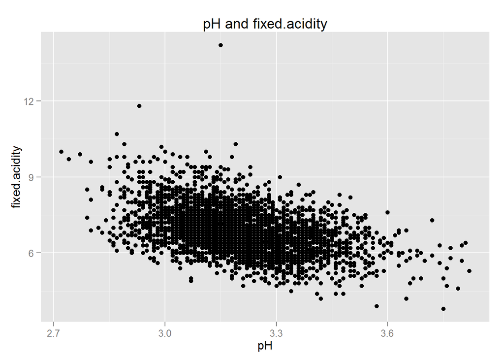

Plotting with noise to remove the overplotting.

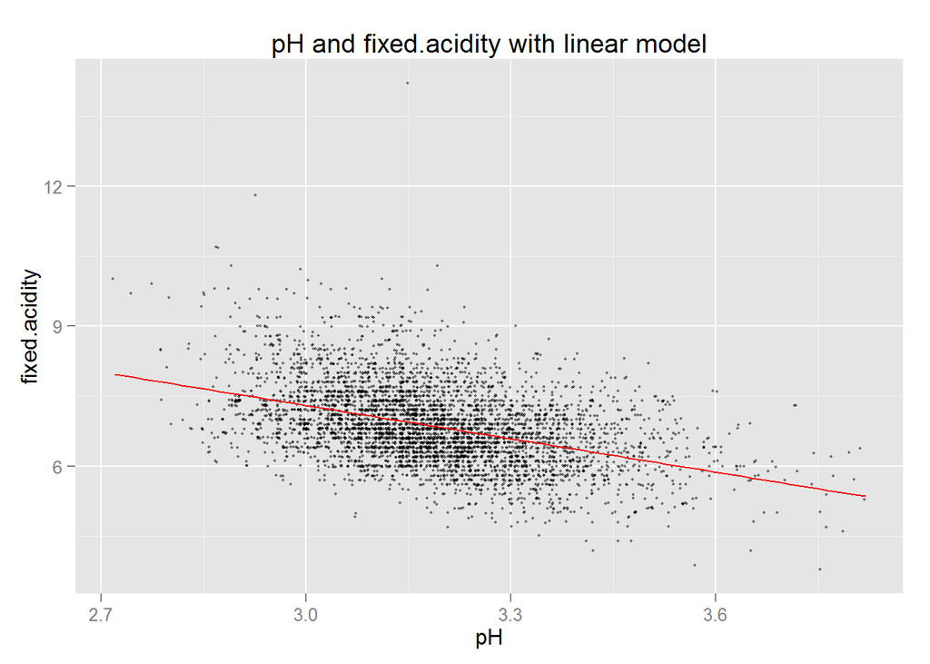

It looks like a negative correlation between pH and **fixed.acidity** which is trivial as pH is an indicator of the acidity.The above plot also shows a linear regression line. The correlation between pH and fixed acidity is **-0.43**

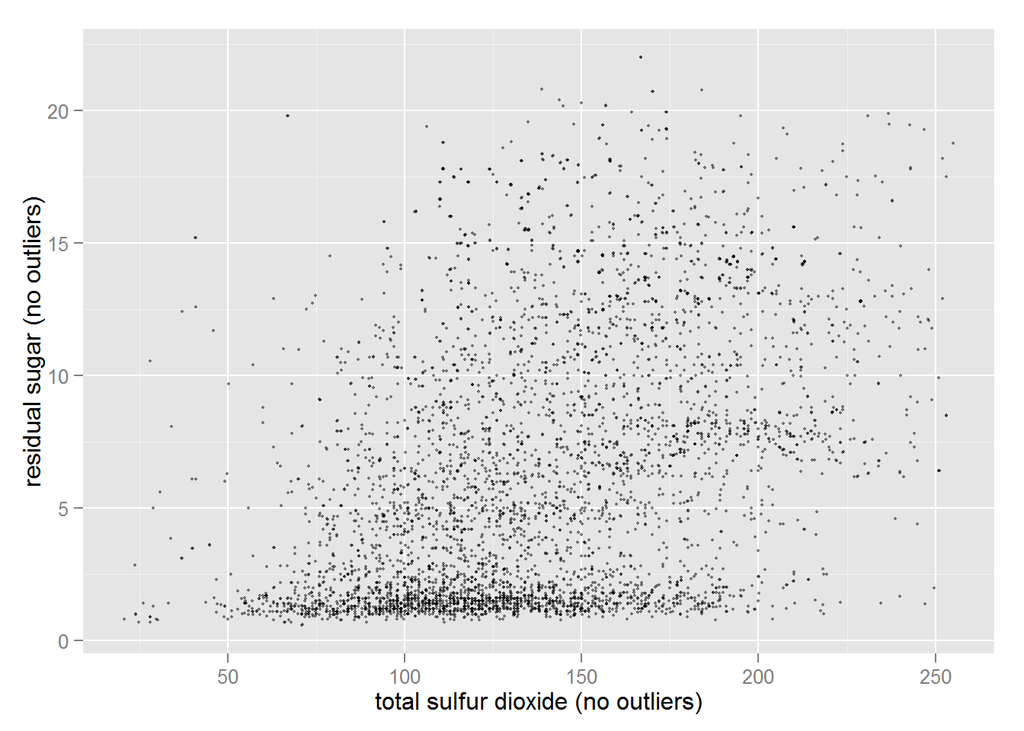

```
## geom_smooth: colour = darkred
## stat_smooth: method = lm, formula = y ~ x, se = TRUE, n = 80, fullrange = FALSE, level = 0.95, na.rm = FALSE
## position_identity: (width = NULL, height = NULL)
```

There are too many points on the lower side of the residual sugar even after removing the outliers but on the upper side it shows a linear relationship. The correlation between residual sugar and total sufur dioxide is **0.41**

Same relationships can also be found in between

- alcohol and residual.sugar (correlation **-0.46**)
- alcohol and total.sulfur.dioxide (correlation **-0.45**)

Plots are below

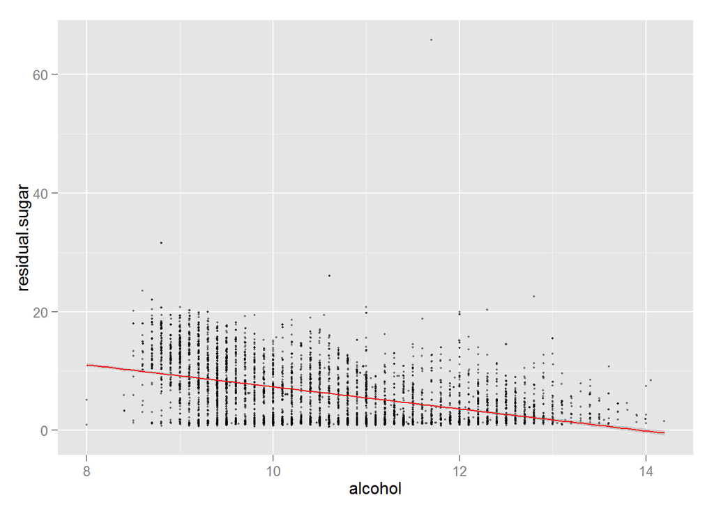

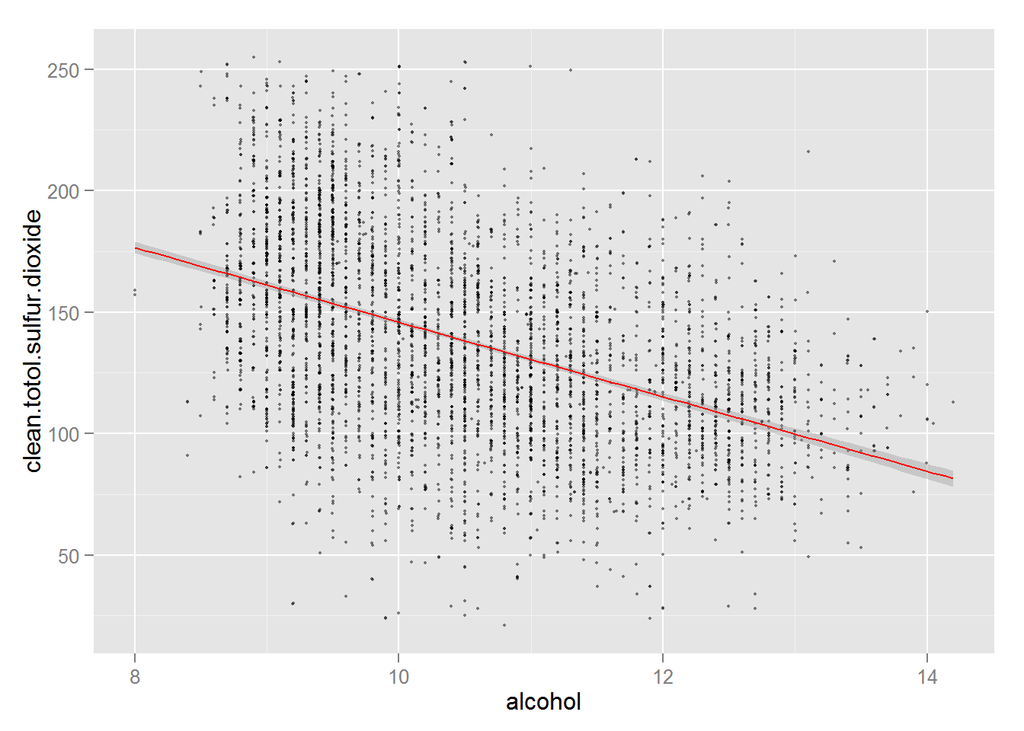

# Bivariate Analysis

### Talk about some of the relationships you observed in this part of the

investigation. How did the feature(s) of interest vary with other features in the dataset? Based on the correlation coefficients between the various pairs the most strong relationship is found beween the following pairs

| Sr No. | Feature1 | Feature2 | Correlation |
| --- | --- | --- | --- |
| 1. | pH | fixed.acidity | -0.4258 |
| 2. | total.sulfur.dioxide | residual.sugar | 0.4014 |
| 3. | alcohol | sugar | -0.4506 |
| 4. | achohol | total.sulfur.dioxide | -0.4488 |

I have not taken the quality in calculating the correlation as I just wanted to know the correlation between the features themselves.

### Did you observe any interesting relationships between the other features

(not the main feature(s) of interest)?

Yes, as shown in the plots and the table above, I found some relationships which were not evident directly. Plotting variables helped to look into these in more detail.

The relationship between the pH value and the fixed.acidity is trivial as pH value is a representation of the acidity. But the relationship between the  
total sulfurdioxide and the residual sugar , alcohol and residual sugar may help us in explaining the variance which will be explored in the next section.

# Multivariate Plots Section

Before starting the multivariate analysis I want to convert more features into categorical values. These are

- **Alcohol** It is cut into 7 factors from 8 to 15 with an interval of 1

```
##    1    2    3    4    5    6    7
##  317 1606 1256  906  675  131    7
```

- residual.sugar

Since the residual.sugar is bimodal on the log10 scale so I convert it into the orders of low and high based on its median.

```
##    Min. 1st Qu.  Median    Mean 3rd Qu.    Max.
##   0.600   1.700   5.200   6.391   9.900  65.800
```

```
##  low high
## 2469 2429
```

- quality

quality is cut into 3 categories of **poor, average and good**

```r
summary(data$quality.cat)
```

```
##    poor average    good
##     183    3655    1060
```

Since density and alcohol are co-related with the quality. lets take a look at them by quality

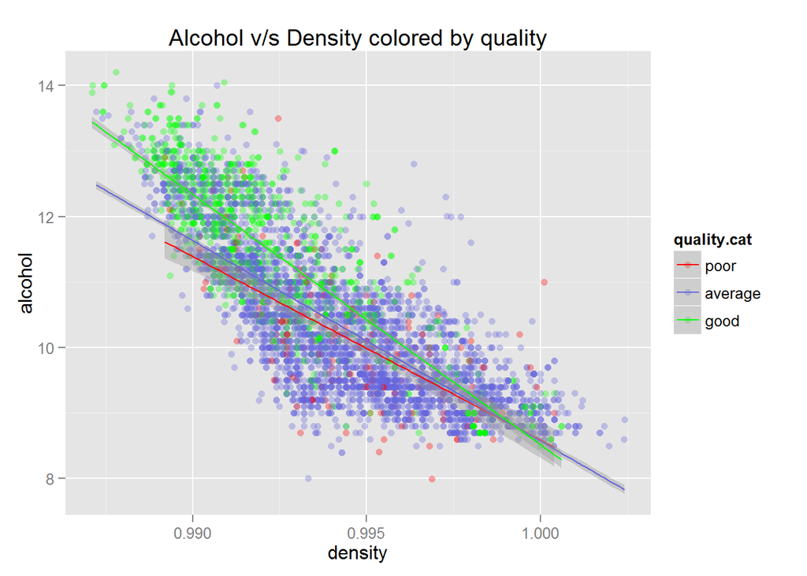

There are some points at the top left telling a better quality wine is with more alcohol and less density. Also the linear model lines tell that we get better quality at low density and high alcohol level. The good quality wines are separable at these levels.

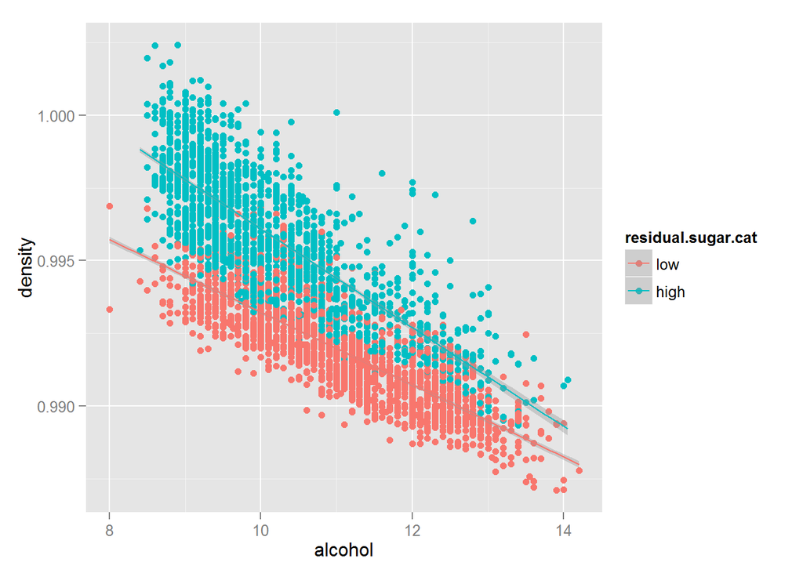

This plot shows the relationship between the density, alcohol and the residual sugar. Following relatiionships are evident

- for more alcohol we have less sugar content and also the density tends to be low
- high density correlates to high sugar content.
- There is negative relationship between the the alcohol content and density of the wines

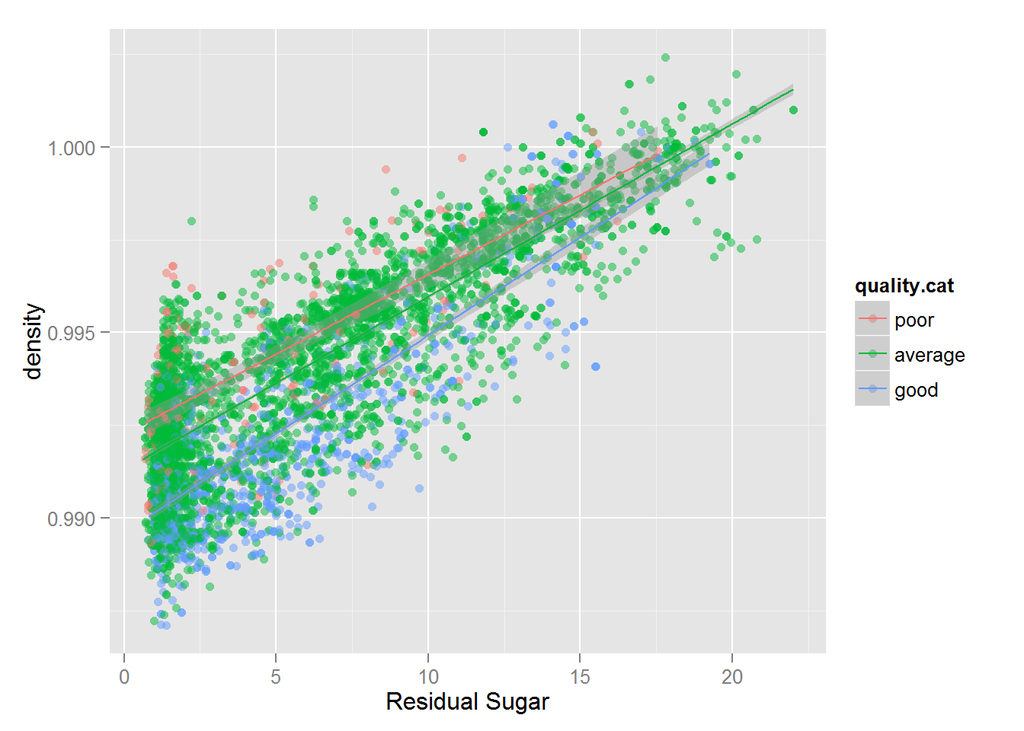

### Now making a predictive model

In the first iteration I tool all the features in the model

```r
data$quality.num <- as.numeric.factor(data$quality)
m1 <- lm(quality.num ~ fixed.acidity , data=data)
m2 <- update(m1, ~ . + volatile.acidity)
m3 <- update(m2, ~ . + citric.acid)
m4 <- update(m3, ~ . + residual.sugar)
m5 <- update(m4, ~ . + chlorides)
m6 <- update(m5, ~ . + free.sulfur.dioxide)
m7 <- update(m6, ~ . + total.sulfur.dioxide)
m8 <- update(m7, ~ . + density)
m9 <- update(m8, ~ . + pH)
m10 <- update(m9, ~ . + sulphates)
m11 <- update(m10, ~ . + alcohol)

mtable(m1,m2,m3,m4,m5,m6,m7,m8,m9,m10,m11)
```

```
##
## Calls:
## m1: lm(formula = quality.num ~ fixed.acidity, data = data)
## m2: lm(formula = quality.num ~ fixed.acidity + volatile.acidity,
##     data = data)
## m3: lm(formula = quality.num ~ fixed.acidity + volatile.acidity +
##     citric.acid, data = data)
## m4: lm(formula = quality.num ~ fixed.acidity + volatile.acidity +
##     citric.acid + residual.sugar, data = data)
## m5: lm(formula = quality.num ~ fixed.acidity + volatile.acidity +
##     citric.acid + residual.sugar + chlorides, data = data)
## m6: lm(formula = quality.num ~ fixed.acidity + volatile.acidity +
##     citric.acid + residual.sugar + chlorides + free.sulfur.dioxide,
##     data = data)
## m7: lm(formula = quality.num ~ fixed.acidity + volatile.acidity +
##     citric.acid + residual.sugar + chlorides + free.sulfur.dioxide +
##     total.sulfur.dioxide, data = data)
## m8: lm(formula = quality.num ~ fixed.acidity + volatile.acidity +
##     citric.acid + residual.sugar + chlorides + free.sulfur.dioxide +
##     total.sulfur.dioxide + density, data = data)
## m9: lm(formula = quality.num ~ fixed.acidity + volatile.acidity +
##     citric.acid + residual.sugar + chlorides + free.sulfur.dioxide +
##     total.sulfur.dioxide + density + pH, data = data)
## m10: lm(formula = quality.num ~ fixed.acidity + volatile.acidity +
##     citric.acid + residual.sugar + chlorides + free.sulfur.dioxide +
##     total.sulfur.dioxide + density + pH + sulphates, data = data)
## m11: lm(formula = quality.num ~ fixed.acidity + volatile.acidity +
##     citric.acid + residual.sugar + chlorides + free.sulfur.dioxide +
##     total.sulfur.dioxide + density + pH + sulphates + alcohol,
##     data = data)
##
## =========================================================================================================================================================
##                           m1          m2          m3          m4          m5          m6          m7          m8          m9          m10         m11
## ---------------------------------------------------------------------------------------------------------------------------------------------------------
## (Intercept)             6.696***    7.210***    7.214***    7.232***    7.499***    7.447***    7.519***   254.194***  291.987***  299.961***  226.491***
##                        (0.103)     (0.107)     (0.108)     (0.108)     (0.107)     (0.112)     (0.111)      (8.513)     (8.760)     (8.747)    (23.375)
## fixed.acidity          -0.119***   -0.124***   -0.122***   -0.117***   -0.121***   -0.118***   -0.100***     0.053***    0.171***    0.176***    0.121***
##                        (0.015)     (0.015)     (0.015)     (0.015)     (0.015)     (0.015)     (0.015)      (0.015)     (0.017)     (0.017)     (0.023)
## volatile.acidity                   -1.735***   -1.741***   -1.689***   -1.547***   -1.523***   -1.308***    -1.860***   -1.842***   -1.820***   -1.873***
##                                    (0.122)     (0.124)     (0.124)     (0.122)     (0.123)     (0.123)      (0.116)     (0.113)     (0.113)     (0.114)
```

[output cut: 15 more lines]

```
##                                                                                                                                     (0.097)     (0.102)
## alcohol                                                                                                                                          0.100***
##                                                                                                                                                 (0.030)
## ---------------------------------------------------------------------------------------------------------------------------------------------------------
## R-squared                  0.013       0.052       0.052       0.057       0.093       0.094       0.113       0.244       0.274       0.285       0.286
## adj. R-squared             0.013       0.051       0.051       0.057       0.093       0.093       0.112       0.243       0.273       0.283       0.285
## sigma                      0.880       0.863       0.863       0.860       0.844       0.844       0.835       0.771       0.756       0.750       0.749
## F                         64.080     133.891      89.284      74.586     100.908      84.563      89.011     197.225     204.779     194.249     178.013
## p                          0.000       0.000       0.000       0.000       0.000       0.000       0.000       0.000       0.000       0.000       0.000
## Log-likelihood         -6322.771   -6224.180   -6224.120   -6209.668   -6114.231   -6112.896   -6060.905   -5665.698   -5567.158   -5531.095   -5525.346
## Deviance                3791.367    3641.766    3641.678    3620.250    3481.884    3479.986    3406.887    2903.064    2788.457    2747.656    2741.206
## AIC                    12651.543   12456.360   12458.240   12431.336   12242.462   12241.792   12139.811   11351.397   11156.315   11086.190   11076.691
## BIC                    12671.032   12482.346   12490.723   12470.315   12287.939   12293.764   12198.280   11416.352   11227.766   11164.137   11161.134
## N                       4898        4898        4898        4898        4898        4898        4898        4893        4893        4893        4893
## =========================================================================================================================================================
```

# Multivariate Analysis

### Talk about some of the relationships you observed in this part of the

investigation. Were there features that strengthened each other in terms of looking at your feature(s) of interest?

I used the multivariate analysis to quantify more data from the bi-variate analysis. The plots are redone with taking some feature as a colored factor. Relationships like as density increases the residual.sugar also increases. There is also a very strong correlation between the density and residual.sugar .

### Were there any interesting or surprising interactions between features?

The most interesting interaction comes between the density, alcohol and residual sugar. With the decrease density the alcohol content increases but the residual sugar in the wines decrease. There is clear line of separation between them based on residual sugar.

The most important part that I found by the uni-variate, bi-variate and multi-variate analysis is that there is too much overlap between the features and nothing can be conclusively said about the wine quality from its chemical composition.

### OPTIONAL: Did you create any models with your dataset? Discuss the strengths and limitations of your model.

Yes, 11 linear models were created with adding features one by one. The highest r-squared value came to be **0.286** when all the features are incorporated. The variance explaination is not much and hence it cannot be said that we have a good model for prediction of wine quality.

#### Limitations

- The model doesn’t explain much of the variance for the quality of wine. The r-squared value is just 0.286.
- The reason for the above may be because we don’t have enough data. Most of the data is of average quality and many features overlap between the good quality and average quality hence a consensus cannot be found between the important features and their values.
- There is strong correlation between features such as free.sulfur.dioxide and the total.sulrfur dioxide ; density and residual.sugar. This also leads to problem of multicollinearty.

# Final Plots and Summary

### Plot One

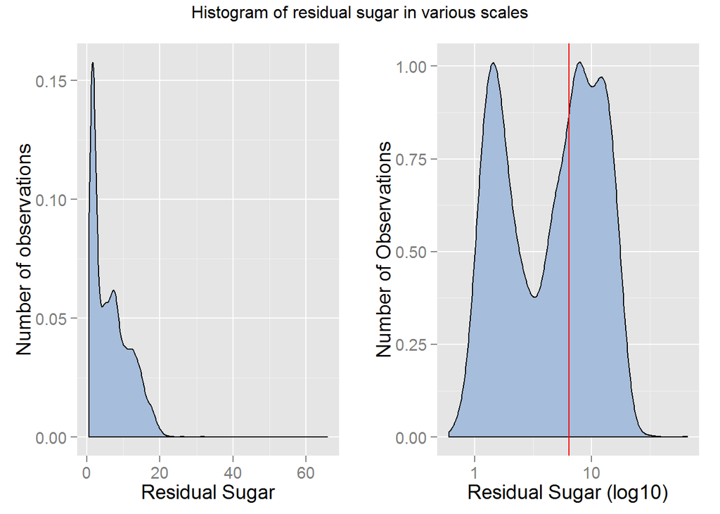

### Description One

This tells us that there is clear distinction in the wines data based on the residual sugar and it is explored more in the next plot.

### Plot Two

[figure not shown]

### Description Two

This plot shows the three-way relationship between density, alcohol and residual sugar. The idea of breaking the residual sugar into a factor comes from the first plot as it shows the bimodal relation ship. The median is chosen as the breakpoint.

This plot shows the strong relationship between the density-alcohol and density-residual sugar. The density decreases with the increase in alcohol level and high density leads to high level of sugar. The plot also build upon the hypothesis of previous plot that in the wines data there is clear distinction by the residual sugar level.

### Plot Three

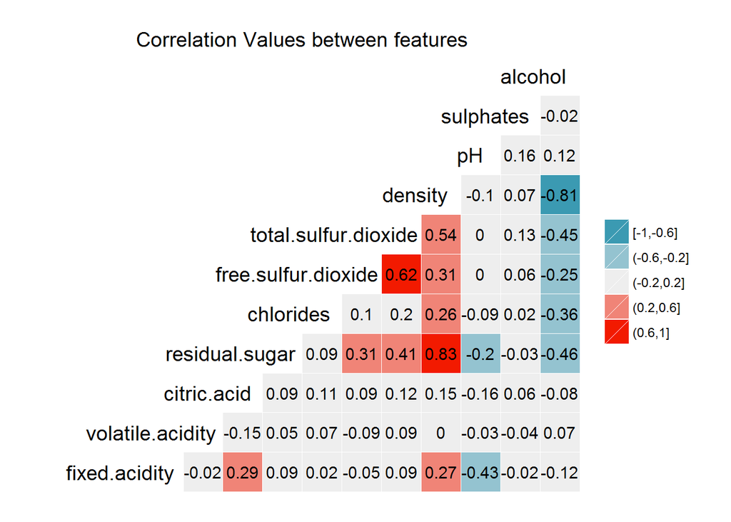

### Description Three

This plot/matrix brings out the best of correlations and displays it in easier to read formats.

# Reflection

This was an intense project compared to previous ones. The data was just thrown and I needed to find the patterns. I chose the White Wines dataset as I didn’t had enough time to dig into other datasets and this was also a tidy one so I thought it will be easier. I started with exploring through the features and and then finding relationship between them to making a model to predict the wine quality.Some features are correlated strongly and many are not. The prediction model doesn’t do well as the features are variable throughout the quality level. There is also a strong bias towards the average quality wines as the data for the high and poor quality is considerably less. The plots with density, residual sugar and alcohol were most motivating as looking at them gave some confidence of finding something.

The future work in this can be done with some more data about the good quality wines. Using a better and calculated approach to feature selection can improve the model with less features also. Also I haven’t used the dplyr, etc. packages which can be used to make more intricate analysis.

In the end I started with zero knowledge of wines but now I know what components affects wine quality. The knowledge is not sufficient to be wine connoisseur but it’s better than a blind guess.

# References

1. https://en.wikipedia.org/wiki/White_wine
2. http://www.r-bloggers.com/from-continuous-to-categorical/
3. Thinking fast and slow , Chapter 21 : Intutions vs Formulas ; Daniel Kahneman
4. https://cran.r-project.org/web/packages/corrplot/vignettes/corrplot-intro.html
5. https://en.wikipedia.org/wiki/White_wine
6. http://docs.ggplot2.org/0.9.3.1/guide_legend.html
7. http://stackoverflow.com/a/4788102
8. https://briatte.github.io/ggcorr/